# Race and the Prison/Jail System

Problem: Through the data collected by Vera Institute, I want to see if there is a racial bias towards black people in the prison and jail system.

```r
#Extracting data
urlfile = "https://raw.githubusercontent.com/vera-institute/incarceration-trends/master/incarceration_trends.csv"

#Naming the dataset
incar_trends <- read_csv(url(urlfile))
#Looking at the columns
incar_var <- colnames(incar_trends)

#Different regions
incar_regions <- unique(incar_trends$region)
```

Basic Look at the data set, incar_pop looks at the change over time on the increase of the US population and incar_jnp looks specifically at prisons and jails.

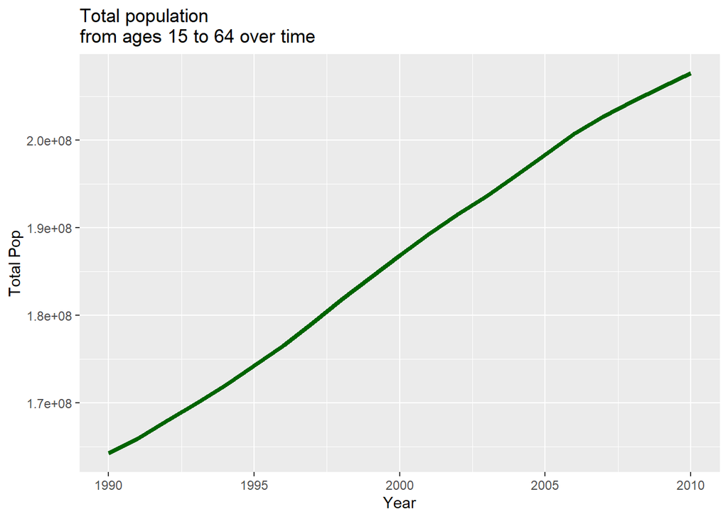

```r
#Looking at the amount of people that are ages 15 to 64 from 1970 to 2010
incar_pop <- incar_trends %>%
  group_by(year) %>%
  summarize(total_pop_15to64 = sum(total_pop_15to64)) %>%
  filter(year >= '1990' & year <= '2010')

#Graph of incar_pop
pop_line <- ggplot(incar_pop, aes(year, total_pop_15to64)) + geom_line(color = 'darkgreen', size = 1.5) + labs(x = 'Year', y = 'Total Pop') + ggtitle ('Total population
from ages 15 to 64 over time')
pop_line
```

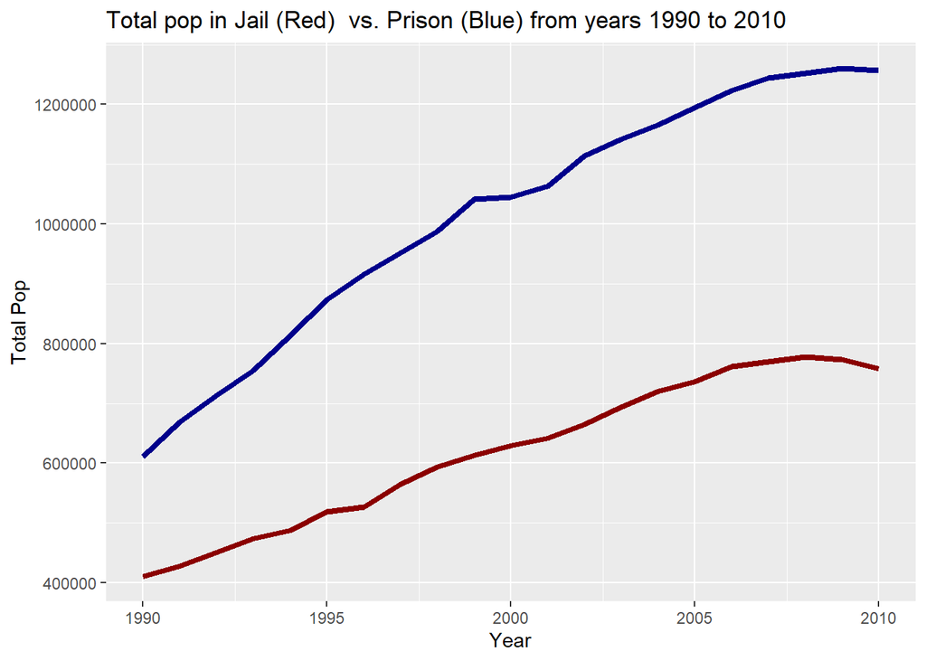

```r
#Looking at the amount of people in prison and jail from 1990 to 2010
incar_jnp <- incar_trends %>%
  group_by(year) %>%
  summarize(total_jail_pop = sum(total_jail_pop,na.rm=TRUE),
            total_prison_pop = sum(total_prison_pop,na.rm=TRUE)) %>%
  filter(year >= '1990' & year <= '2010')

#Graph of incar_jnp
jnp_lines <- ggplot(incar_jnp) +
  geom_line(aes(x = year, y = total_jail_pop), size = 1.5, color = 'darkred') +
  geom_line(aes(x = year, y = total_prison_pop), size = 1.5, color = 'darkblue') +
  ylab('Total Pop') +
  xlab('Year') +
  ggtitle('Total pop in Jail (Red)  vs. Prison (Blue) from years 1990 to 2010')
jnp_lines
```

There has been a sharp increase in terms of total population that can go to jail in the US. The prison and jail population also have an increase but for the most part there are way more people going to prison. At the start of the data, there are way more people in prison compared to jail but the increase for prison is sharper compared to jail and the jail population has occasional dips.

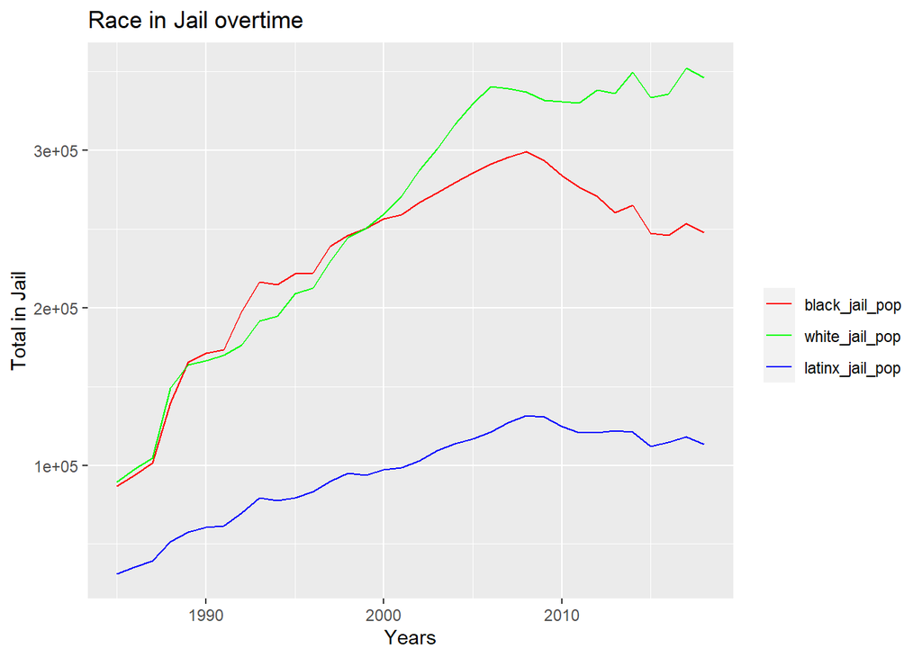

```r
#Race over time in Jail
incar_jail_race <- incar_trends %>%
  filter(year >= '1985') %>%
  group_by(year) %>%
   summarize(black_jail_pop = sum(black_jail_pop,na.rm = TRUE),
            white_jail_pop = sum(white_jail_pop, na.rm = TRUE),
            latinx_jail_pop = sum(latinx_jail_pop, na.rm = TRUE),
            aapi_jail_pop = sum(aapi_jail_pop,na.rm = TRUE),
            native_jail_pop = sum(native_jail_pop,na.rm = TRUE),
            other_race_jail_pop = sum(other_race_jail_pop,na.rm = TRUE))

#Graph of incar_jail_race
jail_line <-  ggplot(data = incar_jail_race, aes(x = year)) +
  geom_line(aes(y = black_jail_pop, colour = 'black_jail_pop')) +
  geom_line(aes(y = white_jail_pop, colour = 'white_jail_pop')) +
  geom_line(aes(y = latinx_jail_pop, colour = 'latinx_jail_pop')) +
  xlab('Years') +
  scale_colour_manual('',
                      breaks = c('black_jail_pop','white_jail_pop','latinx_jail_pop'),
                      values = c('red','green','blue')) +
  scale_y_continuous('Total in Jail') +
  labs(title = 'Race in Jail overtime')
jail_line
```